| title: “UEFA Championship Win Probabilities” |
| --- |
| author: “Soren Johansen” |
| date: “27 3 2020” |
| output: html_document |

## Understand the problem

The problem I want to model is a about European soccer. The hypothesis I want to test is if there is a home advantage during European UEFA Championship and also to see if decompose the teams into which is more attach versus more defense playing strategy. The data I have used is from Kaggle. The model I have used is called the Poisson random effects model.

We indicate the number of points scored by the home and the away team in the g-th game of the season (175 games) as $y_{g1}$ and $y_{g2}$ respectively.

The vector of observed counts y=($y_{g1}$, $y_{g2}$) is modelled as independent Poisson: $y_{gj}|\theta_{gj}~Possion(\theta_{gj})$ playing at home (j=1) and away (j=2), respectively. We model these parameters according to a formulation that has been used widely in the statistical literature, assuming a log-linear random effect model:
$$log \theta_{g1}=home+att_{h(g)}+def_{a(g)}$$
$$log \theta_{g2}=att_{a(g)}+def_{h(g)}$$
A more detailed study of the model can be found [here](https://discovery.ucl.ac.uk/id/eprint/16040/1/16040.pdf) with Italian football(Serie A championship 1991-1992) and an implementation in pymc3 is [here](https://docs.pymc.io/notebooks/rugby_analytics.html) on Rugby data. During the European Championship every team is assigned to specific football stadium and will play all their matches at the same stadium in the first round of the tournament. The notion of home advantage does make sense.

## Plan and properly collect relevant data

```r
Soccer <- read.csv("~/Downloads/results.csv")
euro <- Soccer %>%
    filter(tournament=="UEFA Euro") %>%
    filter(year(date)>=2000)
```

This gives me:

- 175 matches (nrow(euro))
- 32 different European countries over
- UEFA Championships in 2000(Belgium/Netherlands), 2004(Portugal), 2008(Austria/Switzerland), 2012(Poland/Ukraine) and 2016(France)

## Explore data

Some descriptive statistics:

```r
summary(euro$home_score)
```

```
##    Min. 1st Qu.  Median    Mean 3rd Qu.    Max.
##   0.000   0.000   1.000   1.314   2.000   6.000
```

```r
summary(euro$away_score)
```

```
##    Min. 1st Qu.  Median    Mean 3rd Qu.    Max.
##   0.000   0.000   1.000   1.103   2.000   4.000
```

and standard deviation

```r
sd(euro$home_score)
```

```
## [1] 1.231097
```

```r
sd(euro$away_score)
```

```
## [1] 0.9830418
```

I see that on average the home team scores more than the away team but that the standard deviation for home teams is higher than the away teams. The sum of all home scores and away scores can be visualized as this:

Total home and away scores

```r
home_sum_scores<-euro %>%
  group_by(home_team) %>% summarise(total_home = sum(home_score))

away_sum_scores<-euro %>%
  group_by(away_team) %>% summarise(total_away = sum(away_score))
home_away_sum<-cbind(home_sum_scores,away_sum_scores)
```

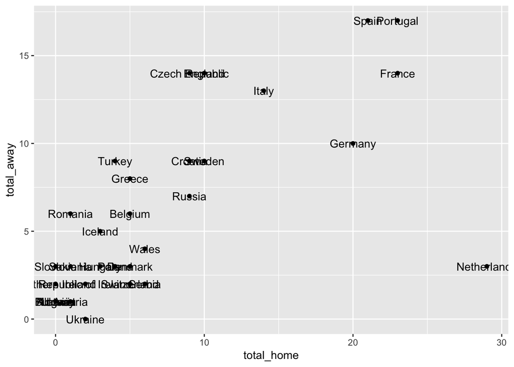

```r
f <- ggplot(home_away_sum, aes(total_home,total_away))
f + geom_text(aes(label=home_team))+geom_point()
```

Interesting to see the cluster of teams in upper right corner e.g. Spain, Portugal France, Germany.

## Postulate a model

The model I use, has already been presented above. Here is the jags code:

```r
mod_string = " model {
for (i in 1:length(date)) {
  home_score[i] ~ dpois(theta_home[i])
  away_score[i] ~ dpois(theta_away[i])
  theta_home[i] = exp(home+att[home_ind[i]]+def[away_ind[i]])
  theta_away[i] = exp(att[away_ind[i]]+def[home_ind[i]])
  }

for (i in 1:max(home_ind)) {
  att_star[i] ~ dnorm(mu_att, tau_att)
  def_star[i] ~ dnorm(mu_def, tau_def)
  att[i]=att_star[i]-mean(att_star)
  def[i]=def_star[i]-mean(def_star)
}

mu_att ~ dnorm(0.0,1000)
tau_att ~ dgamma(0.01,0.01)
mu_def ~ dnorm(0.0,1000)
tau_def ~ dgamma(0.01, 0.01)
home ~ dnorm(0.0,1)
} "
```

You can find the full script [here](https://github.com/sojohan/mcmc_example/blob/master/project.R)

## Fit the model

Fit Summary

|  | mean | sd | median | X2.5. | X10. | X90. | X97.5. | n.iter | n.eff |
| --- | --- | --- | --- | --- | --- | --- | --- | --- | --- |
| att[1] | 0.063 | 0.194 | 0.056 | -0.310 | -0.174 | 0.310 | 0.469 | 60000 | 27301.212 |
| att[2] | 0.206 | 0.155 | 0.202 | -0.079 | 0.011 | 0.409 | 0.519 | 60000 | 9278.830 |
| att[3] | 0.275 | 0.175 | 0.269 | -0.043 | 0.054 | 0.505 | 0.636 | 60000 | 6857.261 |
| att[4] | 0.011 | 0.180 | 0.011 | -0.351 | -0.215 | 0.236 | 0.370 | 60000 | 31617.324 |
| att[5] | 0.101 | 0.152 | 0.096 | -0.187 | -0.087 | 0.299 | 0.408 | 60000 | 18425.294 |
| att[6] | 0.178 | 0.145 | 0.174 | -0.094 | -0.005 | 0.368 | 0.472 | 60000 | 10665.777 |
| att[7] | 0.170 | 0.228 | 0.151 | -0.233 | -0.099 | 0.472 | 0.677 | 60000 | 11830.400 |
| att[8] | 0.259 | 0.159 | 0.255 | -0.037 | 0.057 | 0.466 | 0.578 | 60000 | 8377.248 |
| att[9] | 0.029 | 0.165 | 0.028 | -0.295 | -0.178 | 0.240 | 0.359 | 60000 | 31077.104 |
| att[10] | 0.082 | 0.162 | 0.078 | -0.231 | -0.119 | 0.292 | 0.414 | 60000 | 23257.857 |
| def[1] | 0.013 | 0.154 | 0.012 | -0.298 | -0.176 | 0.203 | 0.329 | 60000 | 30681.418 |
| def[2] | -0.010 | 0.123 | -0.008 | -0.263 | -0.163 | 0.143 | 0.231 | 60000 | 36134.761 |
| def[3] | -0.033 | 0.137 | -0.027 | -0.326 | -0.207 | 0.133 | 0.227 | 60000 | 30377.519 |
| def[4] | 0.027 | 0.141 | 0.025 | -0.253 | -0.146 | 0.204 | 0.313 | 60000 | 31707.059 |
| def[5] | -0.050 | 0.128 | -0.044 | -0.322 | -0.215 | 0.105 | 0.191 | 60000 | 25106.198 |
| def[6] | -0.120 | 0.135 | -0.108 | -0.417 | -0.299 | 0.040 | 0.116 | 60000 | 11195.683 |
| def[7] | 0.204 | 0.197 | 0.174 | -0.103 | -0.018 | 0.472 | 0.665 | 60000 | 5574.174 |
| def[8] | -0.183 | 0.154 | -0.166 | -0.527 | -0.388 | -0.001 | 0.072 | 60000 | 7020.389 |
| def[9] | -0.007 | 0.137 | -0.005 | -0.291 | -0.178 | 0.161 | 0.261 | 60000 | 33061.597 |
| def[10] | 0.045 | 0.131 | 0.042 | -0.214 | -0.116 | 0.212 | 0.315 | 60000 | 31157.153 |

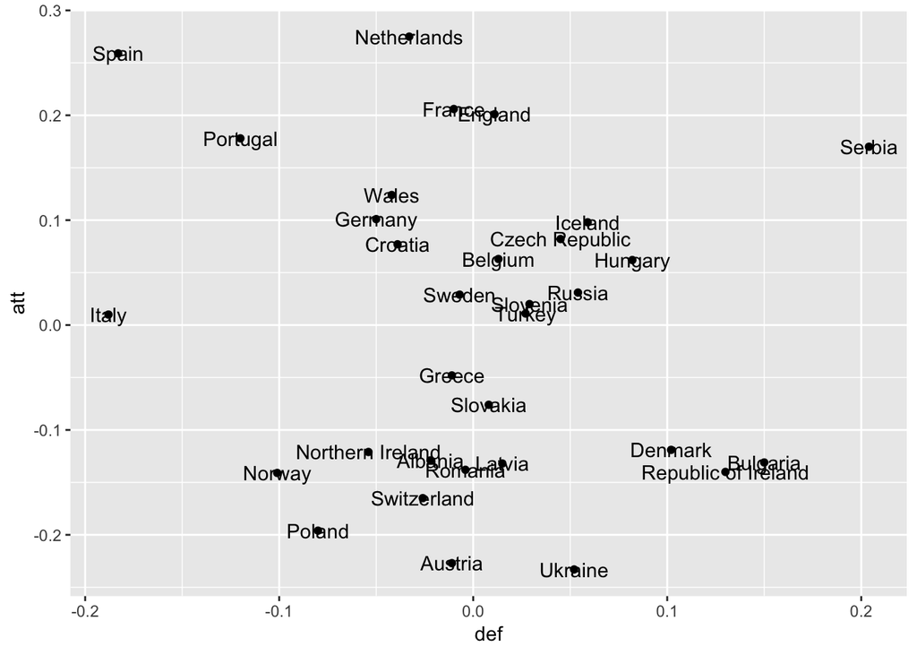

## Check the model

Here is the first couple of traces:

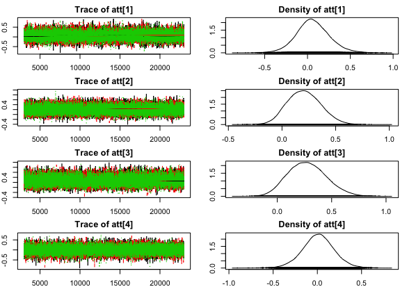

Traces for att

Here is the Gelman scale factor is 1.00 except tau_att which is 1.02.

```
##    variable Point est. Upper C.I.
## 1    att[1]       1.00       1.00
## 2    att[2]       1.00       1.00
## 3    att[3]       1.00       1.00
## 4    att[4]       1.00       1.00
## 5    att[5]       1.00       1.00
## 6    att[6]       1.00       1.00
## 7    att[7]       1.00       1.00
## 8    att[8]       1.00       1.00
## 9    att[9]       1.00       1.00
## 10  att[10]       1.00       1.00
## 11     home       1.00       1.00
## 12   mu_att       1.00       1.00
## 13  tau_att       1.02       1.02
## 14  tau_def       1.00       1.00
```

```
##                home       mu_att       mu_def    tau_att    tau_def
## Lag 0   1.000000000  1.000000000  1.000000000 1.00000000 1.00000000
## Lag 1   0.477421216  0.386951529  0.546749185 0.89463747 0.87521898
## Lag 5   0.168404567  0.090893106  0.176854367 0.66689008 0.63336734
## Lag 10  0.106557209  0.010626300  0.044100092 0.46883586 0.43682901
## Lag 50 -0.003242774 -0.004098353 -0.009329736 0.01573797 0.00949689
```

Note there is some autocorrelation in parameter tau_att.

## Use the model

I can simulate a tournament with our model and calculate the probability that Denmark will win. Let me take Denmark against (Spain, Germany, Sweden, Netherlands). Here is code Denmark against Spain:

```r
theta_home= exp(mod_csim[,"home"]+mod_csim[,"att[16]"]+mod_csim[,"def[8]"])
theta_away=exp(mod_csim[,"att[8]"]+mod_csim[,"def[16]"])
n_sim=length(theta_home)
den_spain=rpois(n=n_sim,theta_home)
spain_den=rpois(n=n_sim,theta_away)
mean(den_spain>spain_den)
```

Here are the probabilities that Denmark will win over Spain, Germany, Sweden, Netherlands:

Win Probabilities in%

| Team | Denmark |
| --- | --- |
| Spain | 24.91 |
| Sweden | 34.59 |
| Germany | 31.51 |
| Netherlands | 28.36 |